## Report: act_report

- Create a **250-word-minimum written report** called "act_report.pdf" or "act_report.html" that communicates the insights and displays the visualization(s) produced from your wrangled data. This is to be framed as an external document, like a blog post or magazine article, for example.

# WeRateDogs Twitter data Analysis

## Contents

- Introduction
- Insights

## Introduction

WeRateDogs is a Twitter account that rates people's dogs with a humorous comments about the dog. WeRateDogs has over 4 million followers and has received international media coverage. On this page People post pictures of their dogs, then tweets selected photos rating and a humorous comment. Dogs are rated on a scale of one to ten, but are invariably given ratings in excess of the maximum, such as "13/10"

To draw some insights we analysed tweets from this Twitter account. The tweet text contained basic data like the dog ratings, dog name and dog stage. These data was extracted from the tweets and additional data was collected using Twitter APIs and a neural network on the dog pictures to classify the breed of dogs.

## Insights

From the analysis of original tweets(no retweets) from WeRateDogs twitter account , we found some interesting facts;

Followers tweeted mainly from these platforms Twitter for Iphone, Twitter Web, Vine and Tweetdeck. Majority of them tweeted using Twitter for iphone

About 80% of the dog ratings given in the tweets were above the maxmimum of 10, with 1776 as the highest dog rating given. LOL 😅

One important activity in the twitter space is the number of retweets and likes. The tweet **'Here's a doggo realizing you can stand in a pool. 13/10 enlightened af (vid by Tina Conrad)'** was the most retweeted, retweeted 79515 times. The tweet **'Here's a super supportive puppo participating in the Toronto #WomensMarch today. 13/10'** was the most liked with 132810 likes.

While majority of the tweets didn't specify the dog stage, we were still able to assess some who specified the dog stage.

From the picture below, most of the dogs specified were at the Pupper stage(An inexperienced, unfamiliar, or in any way unprepared for the responsibilities associated with being a doggo.), the next common stage was the doggo stage(A big usually older pupper.) and the least common stage was floofer(dogs with seemingly excess fur, Comical amounts of fur on a dog.)

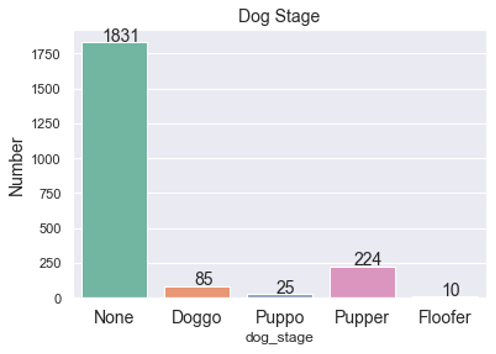